# Stats with R tutorial

Erin W Dickie

September 11, 2016

[Return to SCWG Home](https://camh-scwg.github.io/compucool-oct-2016/)

Please download the following files:

1. messy_demographic.csv
2. messy_cognitive.csv
3. messy_genotype.csv

## Stats sesstion

Load the packages

```r
library(rms)
```

```r
library(ggplot2)
library(car)
library(dplyr)
```

The data should be merged and ready to go from day 1. If not, here’s the code for it:

```r
data1 <- read.csv("~/Downloads/messy_demographic.csv")  # put in the location of the downloaded data file 1
data2 <- read.csv("~/Downloads/messy_cognitive.csv")  # put in the location of the downloaded data file 2
data3 <- read.csv("~/Downloads/messy_genotype.csv")
```

```r
data1[data1==""] <- NA
data1[data1=="missing"] <- NA
data1[data1=="9999"] <- NA

data1$age <- as.numeric(as.character(data1$age))
data1$ethnicity <- factor(data1$ethnicity,levels=c("Cauc","AA","As","In","Other"))
data1$sex <- factor(data1$sex, levels=c(0,1), labels=c("Male","Female"))
data1$dx <- factor(data1$dx, levels=c(0,1), labels=c("Control","Case"))

data2[data2==""] <- NA
data2[data2=="missing"] <- NA
data2[data2=="9999"] <- NA
data2$cog1 <- as.numeric(as.character(data2$cog1))
data2$cog2 <- as.numeric(as.character(data2$cog2))
data2$cog3 <- as.numeric(as.character(data2$cog3))
data2$subID <- gsub(data2$subID,pattern="subject",replacement="SUB_")

data3[data3==""] <- NA
data3[data3=="missing"] <- NA
data3[data3=="9999"] <- NA
data3$genotype <- factor(data3$genotype, levels=c(0,1,2), labels=c("AA","AG","GG"))
data3$subID <- gsub(data3$subID,pattern="subject",replacement="SUB_")

alldata <- merge(data1,data2,by.x="subject_ID",by.y="subID")
alldata <- merge(alldata,data3,by.x="subject_ID",by.y="subID")
```

# HERE WE GO WITH Statistics!

## RESEARCH AIM 4: Linear Regression

#### total_behaviour_score ~ age

Calculate a composite variable by combining multiple variables Note: new variables can be made easily (using dplyr’s mutate verb)

```r
alldata$totalcog <- (alldata$cog1 + alldata$cog3) / alldata$cog2
```

Simple linear regression (two ways: base package and rms)

```r
lm.base <- lm(data=alldata, totalcog ~ age)
lm.rms <- ols(data=alldata, totalcog ~ age)
```

Let’s compare the output’s

```r
lm.base
```

```
##
## Call:
## lm(formula = totalcog ~ age, data = alldata)
##
## Coefficients:
## (Intercept)          age
##     1.78587     -0.01219
```

```r
summary(lm.base)
```

```
##
## Call:
## lm(formula = totalcog ~ age, data = alldata)
##
## Residuals:
##     Min      1Q  Median      3Q     Max
## -1.0529 -0.5054 -0.1940  0.4352  2.3720
##
## Coefficients:
##              Estimate Std. Error t value Pr(>|t|)
## (Intercept)  1.785875   0.172793  10.335  < 2e-16 ***
## age         -0.012192   0.003346  -3.644 0.000313 ***
## ---
## Signif. codes:  0 '***' 0.001 '**' 0.01 '*' 0.05 '.' 0.1 ' ' 1
##
## Residual standard error: 0.6966 on 322 degrees of freedom
##   (26 observations deleted due to missingness)
## Multiple R-squared:  0.03961,    Adjusted R-squared:  0.03663
## F-statistic: 13.28 on 1 and 322 DF,  p-value: 0.0003125
```

```r
anova(lm.base)
```

```
## Analysis of Variance Table
##
## Response: totalcog
##            Df  Sum Sq Mean Sq F value    Pr(>F)
## age         1   6.445  6.4446   13.28 0.0003125 ***
## Residuals 322 156.259  0.4853
## ---
## Signif. codes:  0 '***' 0.001 '**' 0.01 '*' 0.05 '.' 0.1 ' ' 1
```

**Note**: to make the most out of rms package functionality, we need to store summary stats using the datadist() function. That way, when we call summary() on an ols() object (we just made one called “lm.rms”) it will give us useful info.

```r
dd.alldata <- datadist(alldata)
options(datadist="dd.alldata")

lm.rms
```

```
##
## Linear Regression Model
##
## ols(formula = totalcog ~ age, data = alldata)
##
## Frequencies of Missing Values Due to Each Variable
## totalcog      age
##       18        8
##
##
##                 Model Likelihood     Discrimination
##                    Ratio Test           Indexes
## Obs      324    LR chi2     13.09    R2       0.040
## sigma 0.6966    d.f.            1    R2 adj   0.037
## d.f.     322    Pr(> chi2) 0.0003    g        0.160
##
## Residuals
##
##     Min      1Q  Median      3Q     Max
## -1.0529 -0.5054 -0.1940  0.4352  2.3720
##
##           Coef    S.E.   t     Pr(>|t|)
## Intercept  1.7859 0.1728 10.34 <0.0001
## age       -0.0122 0.0033 -3.64 0.0003
```

```r
summary(lm.rms)
```

```
##              Effects              Response : totalcog
##
##  Factor Low High Diff. Effect S.E. Lower 0.95 Upper 0.95
##  age    43  58   15    -0.18  0.05 -0.28      -0.08
```

```r
anova(lm.rms)
```

```
##                 Analysis of Variance          Response: totalcog
##
##  Factor     d.f. Partial SS MS        F     P
##  age          1    6.444638 6.4446382 13.28 3e-04
##  REGRESSION   1    6.444638 6.4446382 13.28 3e-04
##  ERROR      322  156.258677 0.4852754
```

## Visualize results using ggplot2

[figure not shown]

```r
ggplot(data=alldata, aes(y=totalcog, x=age)) +
    geom_point() +
    geom_smooth(method=lm)
```

#### Challenge 1: add a title and change the axis labels

Visualize predicted results using rms

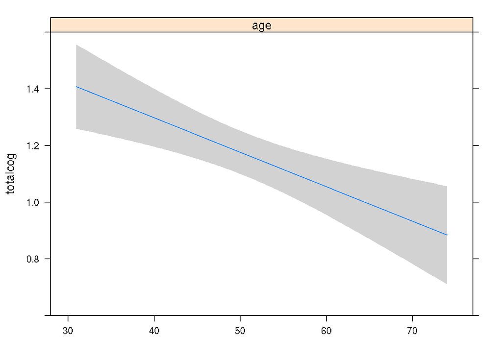

```r
plot(Predict(lm.rms))
```

Check regression assumption of normal residuals

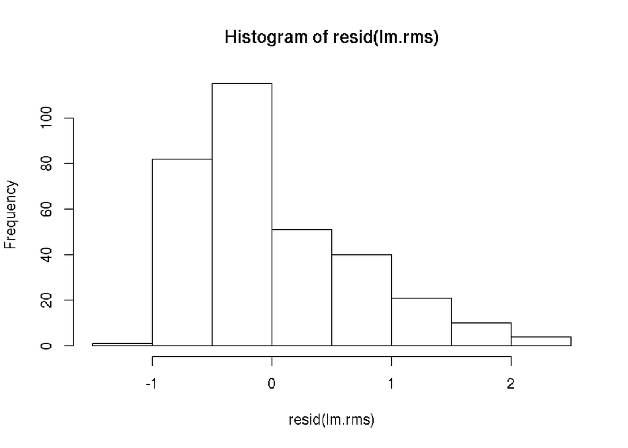

```r
hist(resid(lm.rms))
```

They are not normal! We can look at this formally also:

```r
shapiro.test(resid(lm.rms))
```

```
##
##  Shapiro-Wilk normality test
##
## data:  resid(lm.rms)
## W = 0.9158, p-value = 1.677e-12
```